# Risk Factor Analysis

## Outcome Variable

**Outcome Variable:** haz

## Predictor Variables

**Intervention Variable:** mwtkg

**Adjustment Set:**

unadjusted

## Stratifying Variables

The analysis was stratified on these variable(s):

- agecat
- studyid
- country

## Data Summary

| agecat | studyid | country | mwtkg | n_cell | n |
| --- | --- | --- | --- | --- | --- |
| Birth | ki0047075b-MAL-ED | BANGLADESH | >=58 kg | 47 | 246 |
| Birth | ki0047075b-MAL-ED | BANGLADESH | <52 kg | 156 | 246 |
| Birth | ki0047075b-MAL-ED | BANGLADESH | [52-58) kg | 43 | 246 |
| Birth | ki0047075b-MAL-ED | BRAZIL | >=58 kg | 121 | 184 |
| Birth | ki0047075b-MAL-ED | BRAZIL | <52 kg | 33 | 184 |
| Birth | ki0047075b-MAL-ED | BRAZIL | [52-58) kg | 30 | 184 |
| Birth | ki0047075b-MAL-ED | INDIA | >=58 kg | 36 | 198 |
| Birth | ki0047075b-MAL-ED | INDIA | <52 kg | 123 | 198 |
| Birth | ki0047075b-MAL-ED | INDIA | [52-58) kg | 39 | 198 |
| Birth | ki0047075b-MAL-ED | NEPAL | >=58 kg | 57 | 172 |
| Birth | ki0047075b-MAL-ED | NEPAL | <52 kg | 52 | 172 |
| Birth | ki0047075b-MAL-ED | NEPAL | [52-58) kg | 63 | 172 |
| Birth | ki0047075b-MAL-ED | PERU | >=58 kg | 99 | 276 |
| Birth | ki0047075b-MAL-ED | PERU | <52 kg | 107 | 276 |
| Birth | ki0047075b-MAL-ED | PERU | [52-58) kg | 70 | 276 |
| Birth | ki0047075b-MAL-ED | SOUTH AFRICA | >=58 kg | 166 | 228 |
| Birth | ki0047075b-MAL-ED | SOUTH AFRICA | <52 kg | 23 | 228 |
| Birth | ki0047075b-MAL-ED | SOUTH AFRICA | [52-58) kg | 39 | 228 |
| Birth | ki0047075b-MAL-ED | TANZANIA, UNITED REPUBLIC OF | >=58 kg | 52 | 121 |
| Birth | ki0047075b-MAL-ED | TANZANIA, UNITED REPUBLIC OF | <52 kg | 40 | 121 |
| Birth | ki0047075b-MAL-ED | TANZANIA, UNITED REPUBLIC OF | [52-58) kg | 29 | 121 |
| Birth | ki1000304b-SAS-CompFeed | INDIA | >=58 kg | 14 | 182 |
| Birth | ki1000304b-SAS-CompFeed | INDIA | <52 kg | 141 | 182 |
| Birth | ki1000304b-SAS-CompFeed | INDIA | [52-58) kg | 27 | 182 |
| Birth | ki1017093-NIH-Birth | BANGLADESH | >=58 kg | 2 | 28 |
| Birth | ki1017093-NIH-Birth | BANGLADESH | <52 kg | 23 | 28 |
| Birth | ki1017093-NIH-Birth | BANGLADESH | [52-58) kg | 3 | 28 |
| Birth | ki1017093c-NIH-Crypto | BANGLADESH | >=58 kg | 4 | 27 |
| Birth | ki1017093c-NIH-Crypto | BANGLADESH | <52 kg | 20 | 27 |
| Birth | ki1017093c-NIH-Crypto | BANGLADESH | [52-58) kg | 3 | 27 |

[output cut: 93 more lines]

The following strata were considered:

- agecat: 24 months, studyid: ki0047075b-MAL-ED, country: BANGLADESH
- agecat: 24 months, studyid: ki0047075b-MAL-ED, country: BRAZIL
- agecat: 24 months, studyid: ki0047075b-MAL-ED, country: INDIA
- agecat: 24 months, studyid: ki0047075b-MAL-ED, country: NEPAL
- agecat: 24 months, studyid: ki0047075b-MAL-ED, country: PERU
- agecat: 24 months, studyid: ki0047075b-MAL-ED, country: SOUTH AFRICA
- agecat: 24 months, studyid: ki0047075b-MAL-ED, country: TANZANIA, UNITED REPUBLIC OF
- agecat: 24 months, studyid: ki1017093-NIH-Birth, country: BANGLADESH
- agecat: 24 months, studyid: ki1017093b-PROVIDE, country: BANGLADESH
- agecat: 24 months, studyid: ki1017093c-NIH-Crypto, country: BANGLADESH
- agecat: 24 months, studyid: ki1066203-TanzaniaChild2, country: TANZANIA, UNITED REPUBLIC OF
- agecat: 24 months, studyid: ki1119695-PROBIT, country: BELARUS
- agecat: 24 months, studyid: ki1126311-ZVITAMBO, country: ZIMBABWE
- agecat: 24 months, studyid: ki1148112-LCNI-5, country: MALAWI
- agecat: 6 months, studyid: ki0047075b-MAL-ED, country: BANGLADESH
- agecat: 6 months, studyid: ki0047075b-MAL-ED, country: BRAZIL
- agecat: 6 months, studyid: ki0047075b-MAL-ED, country: INDIA
- agecat: 6 months, studyid: ki0047075b-MAL-ED, country: NEPAL
- agecat: 6 months, studyid: ki0047075b-MAL-ED, country: PERU
- agecat: 6 months, studyid: ki0047075b-MAL-ED, country: SOUTH AFRICA
- agecat: 6 months, studyid: ki0047075b-MAL-ED, country: TANZANIA, UNITED REPUBLIC OF
- agecat: 6 months, studyid: ki1000304b-SAS-CompFeed, country: INDIA
- agecat: 6 months, studyid: ki1017093-NIH-Birth, country: BANGLADESH
- agecat: 6 months, studyid: ki1017093b-PROVIDE, country: BANGLADESH
- agecat: 6 months, studyid: ki1017093c-NIH-Crypto, country: BANGLADESH
- agecat: 6 months, studyid: ki1066203-TanzaniaChild2, country: TANZANIA, UNITED REPUBLIC OF
- agecat: 6 months, studyid: ki1119695-PROBIT, country: BELARUS
- agecat: 6 months, studyid: ki1126311-ZVITAMBO, country: ZIMBABWE
- agecat: 6 months, studyid: ki1148112-LCNI-5, country: MALAWI
- agecat: Birth, studyid: ki0047075b-MAL-ED, country: BANGLADESH
- agecat: Birth, studyid: ki0047075b-MAL-ED, country: BRAZIL
- agecat: Birth, studyid: ki0047075b-MAL-ED, country: INDIA
- agecat: Birth, studyid: ki0047075b-MAL-ED, country: NEPAL
- agecat: Birth, studyid: ki0047075b-MAL-ED, country: PERU
- agecat: Birth, studyid: ki0047075b-MAL-ED, country: SOUTH AFRICA
- agecat: Birth, studyid: ki0047075b-MAL-ED, country: TANZANIA, UNITED REPUBLIC OF
- agecat: Birth, studyid: ki1000304b-SAS-CompFeed, country: INDIA
- agecat: Birth, studyid: ki1017093-NIH-Birth, country: BANGLADESH
- agecat: Birth, studyid: ki1017093c-NIH-Crypto, country: BANGLADESH
- agecat: Birth, studyid: ki1119695-PROBIT, country: BELARUS
- agecat: Birth, studyid: ki1126311-ZVITAMBO, country: ZIMBABWE

### Dropped Strata

Some strata were dropped due to rare outcomes:

- agecat: Birth, studyid: ki1017093-NIH-Birth, country: BANGLADESH
- agecat: Birth, studyid: ki1017093c-NIH-Crypto, country: BANGLADESH
- agecat: 24 months, studyid: ki1066203-TanzaniaChild2, country: TANZANIA, UNITED REPUBLIC OF

## Methods Detail

We’re interested in the causal parameters $E[Y_a]$ for all values of $a \in \mathcal{A}$. These parameters represent the mean outcome if, possibly contrary to fact, we intervened to set all units to have $A=a$. Under the randomization and positivity assumptions, these are identified by the statistical parameters $\psi_a=E_W[E_{Y|A,W}(Y|A=a,W)]$. In addition, we’re interested in the mean of $Y$, $E[Y]$ under no intervention (the observed mean). We will estimate these parameters by using SuperLearner to fit the relevant likelihood factors – $E_{Y|A,W}(Y|A=a,W)$ and $p(A=a|W)$, and then updating our likelihood fit using a joint TMLE.

For unadjusted analyses ($W=\{\}$), initial likelihoods were estimated using Lrnr_glm to estimate the simple $E(Y|A)$ and Lrnr_mean to estimate $p(A)$. For adjusted analyses, a small library containing Lrnr_glmnet, Lrnr_xgboost, and Lrnr_mean was used.

Having estimated these parameters, we will then use the delta method to estimate relative risks and attributable risks relative to a prespecified baseline level of $A$.

# Results Detail

## Results Plots

[figure not shown]

[figure not shown]

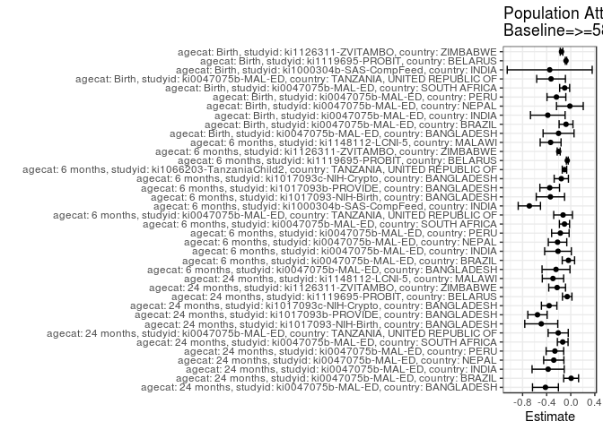

## Results Table

### Parameter: TSM

| agecat | studyid | country | intervention_level | baseline_level | estimate | ci_lower | ci_upper |
| --- | --- | --- | --- | --- | --- | --- | --- |
| Birth | ki0047075b-MAL-ED | BANGLADESH | >=58 kg | NA | -0.8429787 | -1.1278509 | -0.5581066 |
| Birth | ki0047075b-MAL-ED | BANGLADESH | <52 kg | NA | -1.1816667 | -1.3387126 | -1.0246207 |
| Birth | ki0047075b-MAL-ED | BANGLADESH | [52-58) kg | NA | -0.7730233 | -1.0587930 | -0.4872535 |
| Birth | ki0047075b-MAL-ED | BRAZIL | >=58 kg | NA | -0.6612397 | -0.8589885 | -0.4634908 |
| Birth | ki0047075b-MAL-ED | BRAZIL | <52 kg | NA | -0.8078788 | -1.1584653 | -0.4572923 |
| Birth | ki0047075b-MAL-ED | BRAZIL | [52-58) kg | NA | -0.9813333 | -1.3881394 | -0.5745273 |
| Birth | ki0047075b-MAL-ED | INDIA | >=58 kg | NA | -0.6386111 | -0.9519059 | -0.3253163 |
| Birth | ki0047075b-MAL-ED | INDIA | <52 kg | NA | -1.1304878 | -1.3061585 | -0.9548171 |
| Birth | ki0047075b-MAL-ED | INDIA | [52-58) kg | NA | -1.0238462 | -1.3633719 | -0.6843204 |
| Birth | ki0047075b-MAL-ED | NEPAL | >=58 kg | NA | -0.6907018 | -0.9600050 | -0.4213985 |
| Birth | ki0047075b-MAL-ED | NEPAL | <52 kg | NA | -1.0111538 | -1.3378191 | -0.6844886 |
| Birth | ki0047075b-MAL-ED | NEPAL | [52-58) kg | NA | -0.4660317 | -0.6769210 | -0.2551425 |
| Birth | ki0047075b-MAL-ED | PERU | >=58 kg | NA | -0.7005051 | -0.9053872 | -0.4956229 |
| Birth | ki0047075b-MAL-ED | PERU | <52 kg | NA | -1.1633645 | -1.3226703 | -1.0040587 |
| Birth | ki0047075b-MAL-ED | PERU | [52-58) kg | NA | -0.9318571 | -1.1401783 | -0.7235360 |
| Birth | ki0047075b-MAL-ED | SOUTH AFRICA | >=58 kg | NA | -0.5909639 | -0.7385930 | -0.4433347 |
| Birth | ki0047075b-MAL-ED | SOUTH AFRICA | <52 kg | NA | -1.2434783 | -1.5864417 | -0.9005148 |
| Birth | ki0047075b-MAL-ED | SOUTH AFRICA | [52-58) kg | NA | -0.7979487 | -1.1381148 | -0.4577826 |
| Birth | ki0047075b-MAL-ED | TANZANIA, UNITED REPUBLIC OF | >=58 kg | NA | -0.5998077 | -0.8715643 | -0.3280511 |
| Birth | ki0047075b-MAL-ED | TANZANIA, UNITED REPUBLIC OF | <52 kg | NA | -1.2317500 | -1.6125386 | -0.8509614 |
| Birth | ki0047075b-MAL-ED | TANZANIA, UNITED REPUBLIC OF | [52-58) kg | NA | -1.0924138 | -1.5934630 | -0.5913645 |
| Birth | ki1000304b-SAS-CompFeed | INDIA | >=58 kg | NA | -1.0221429 | -1.7222355 | -0.3220503 |
| Birth | ki1000304b-SAS-CompFeed | INDIA | <52 kg | NA | -1.4553191 | -1.6607641 | -1.2498742 |
| Birth | ki1000304b-SAS-CompFeed | INDIA | [52-58) kg | NA | -1.1159259 | -1.4539733 | -0.7778785 |
| Birth | ki1119695-PROBIT | BELARUS | >=58 kg | NA | 1.4052647 | 1.2428617 | 1.5676678 |
| Birth | ki1119695-PROBIT | BELARUS | <52 kg | NA | 0.9032007 | 0.7461268 | 1.0602746 |
| Birth | ki1119695-PROBIT | BELARUS | [52-58) kg | NA | 1.1860076 | 1.0332907 | 1.3387245 |
| Birth | ki1126311-ZVITAMBO | ZIMBABWE | >=58 kg | NA | -0.3439093 | -0.3754150 | -0.3124037 |
| Birth | ki1126311-ZVITAMBO | ZIMBABWE | <52 kg | NA | -0.7804750 | -0.8282854 | -0.7326645 |
| Birth | ki1126311-ZVITAMBO | ZIMBABWE | [52-58) kg | NA | -0.5710183 | -0.6159690 | -0.5260676 |

[output cut: 84 more lines]

### Parameter: E(Y)

| agecat | studyid | country | intervention_level | baseline_level | estimate | ci_lower | ci_upper |
| --- | --- | --- | --- | --- | --- | --- | --- |
| Birth | ki0047075b-MAL-ED | BANGLADESH | NA | NA | -1.0455285 | -1.1715695 | -0.9194875 |
| Birth | ki0047075b-MAL-ED | BRAZIL | NA | NA | -0.7397283 | -0.8996215 | -0.5798350 |
| Birth | ki0047075b-MAL-ED | INDIA | NA | NA | -1.0200505 | -1.1624932 | -0.8776078 |
| Birth | ki0047075b-MAL-ED | NEPAL | NA | NA | -0.7052907 | -0.8627483 | -0.5478331 |
| Birth | ki0047075b-MAL-ED | PERU | NA | NA | -0.9386232 | -1.0507144 | -0.8265319 |
| Birth | ki0047075b-MAL-ED | SOUTH AFRICA | NA | NA | -0.6921930 | -0.8218578 | -0.5625282 |
| Birth | ki0047075b-MAL-ED | TANZANIA, UNITED REPUBLIC OF | NA | NA | -0.9267769 | -1.1425813 | -0.7109724 |
| Birth | ki1000304b-SAS-CompFeed | INDIA | NA | NA | -1.3716484 | -1.5489439 | -1.1943528 |
| Birth | ki1119695-PROBIT | BELARUS | NA | NA | 1.3264008 | 1.1675653 | 1.4852363 |
| Birth | ki1126311-ZVITAMBO | ZIMBABWE | NA | NA | -0.4974449 | -0.5203958 | -0.4744941 |
| 6 months | ki0047075b-MAL-ED | BANGLADESH | NA | NA | -1.2056777 | -1.3231497 | -1.0882058 |
| 6 months | ki0047075b-MAL-ED | BRAZIL | NA | NA | 0.0532131 | -0.0914567 | 0.1978830 |
| 6 months | ki0047075b-MAL-ED | INDIA | NA | NA | -1.2148369 | -1.3332371 | -1.0964367 |
| 6 months | ki0047075b-MAL-ED | NEPAL | NA | NA | -0.5610593 | -0.6737915 | -0.4483272 |
| 6 months | ki0047075b-MAL-ED | PERU | NA | NA | -1.3272488 | -1.4359649 | -1.2185326 |
| 6 months | ki0047075b-MAL-ED | SOUTH AFRICA | NA | NA | -1.0728012 | -1.2026830 | -0.9429194 |
| 6 months | ki0047075b-MAL-ED | TANZANIA, UNITED REPUBLIC OF | NA | NA | -1.3601215 | -1.4821830 | -1.2380600 |
| 6 months | ki1000304b-SAS-CompFeed | INDIA | NA | NA | -1.4006917 | -1.4821813 | -1.3192022 |
| 6 months | ki1017093-NIH-Birth | BANGLADESH | NA | NA | -1.4073821 | -1.4960598 | -1.3187043 |
| 6 months | ki1017093b-PROVIDE | BANGLADESH | NA | NA | -1.0848568 | -1.1613109 | -1.0084028 |
| 6 months | ki1017093c-NIH-Crypto | BANGLADESH | NA | NA | -1.1986783 | -1.2700937 | -1.1272630 |
| 6 months | ki1066203-TanzaniaChild2 | TANZANIA, UNITED REPUBLIC OF | NA | NA | -0.5424765 | -0.5918460 | -0.4931071 |
| 6 months | ki1119695-PROBIT | BELARUS | NA | NA | 0.1143882 | 0.0212298 | 0.2075466 |
| 6 months | ki1126311-ZVITAMBO | ZIMBABWE | NA | NA | -0.8994195 | -0.9257684 | -0.8730707 |
| 6 months | ki1148112-LCNI-5 | MALAWI | NA | NA | -1.6584707 | -1.7281551 | -1.5887863 |
| 24 months | ki0047075b-MAL-ED | BANGLADESH | NA | NA | -1.9431132 | -2.0691678 | -1.8170586 |
| 24 months | ki0047075b-MAL-ED | BRAZIL | NA | NA | 0.0418452 | -0.1263708 | 0.2100613 |
| 24 months | ki0047075b-MAL-ED | INDIA | NA | NA | -1.8439159 | -1.9704751 | -1.7173568 |
| 24 months | ki0047075b-MAL-ED | NEPAL | NA | NA | -1.2752193 | -1.3954783 | -1.1549603 |
| 24 months | ki0047075b-MAL-ED | PERU | NA | NA | -1.7500995 | -1.8705474 | -1.6296516 |
| 24 months | ki0047075b-MAL-ED | SOUTH AFRICA | NA | NA | -1.6220299 | -1.7590593 | -1.4850005 |
| 24 months | ki0047075b-MAL-ED | TANZANIA, UNITED REPUBLIC OF | NA | NA | -2.6058879 | -2.7403043 | -2.4714714 |
| 24 months | ki1017093-NIH-Birth | BANGLADESH | NA | NA | -2.1807945 | -2.2835902 | -2.0779987 |
| 24 months | ki1017093b-PROVIDE | BANGLADESH | NA | NA | -1.5839236 | -1.6672059 | -1.5006413 |
| 24 months | ki1017093c-NIH-Crypto | BANGLADESH | NA | NA | -1.4295331 | -1.5127726 | -1.3462935 |
| 24 months | ki1119695-PROBIT | BELARUS | NA | NA | -0.1312742 | -0.4286264 | 0.1660780 |
| 24 months | ki1126311-ZVITAMBO | ZIMBABWE | NA | NA | -2.4241972 | -2.5387692 | -2.3096253 |
| 24 months | ki1148112-LCNI-5 | MALAWI | NA | NA | -1.8747405 | -1.9558403 | -1.7936407 |

### Parameter: ATE

| agecat | studyid | country | intervention_level | baseline_level | estimate | ci_lower | ci_upper |
| --- | --- | --- | --- | --- | --- | --- | --- |
| Birth | ki0047075b-MAL-ED | BANGLADESH | >=58 kg | >=58 kg | 0.0000000 | 0.0000000 | 0.0000000 |
| Birth | ki0047075b-MAL-ED | BANGLADESH | <52 kg | >=58 kg | -0.3386879 | -0.6639810 | -0.0133949 |
| Birth | ki0047075b-MAL-ED | BANGLADESH | [52-58) kg | >=58 kg | 0.0699555 | -0.3335498 | 0.4734607 |
| Birth | ki0047075b-MAL-ED | BRAZIL | >=58 kg | >=58 kg | 0.0000000 | 0.0000000 | 0.0000000 |
| Birth | ki0047075b-MAL-ED | BRAZIL | <52 kg | >=58 kg | -0.1466391 | -0.5491506 | 0.2558724 |
| Birth | ki0047075b-MAL-ED | BRAZIL | [52-58) kg | >=58 kg | -0.3200937 | -0.7724163 | 0.1322290 |
| Birth | ki0047075b-MAL-ED | INDIA | >=58 kg | >=58 kg | 0.0000000 | 0.0000000 | 0.0000000 |
| Birth | ki0047075b-MAL-ED | INDIA | <52 kg | >=58 kg | -0.4918767 | -0.8510617 | -0.1326917 |
| Birth | ki0047075b-MAL-ED | INDIA | [52-58) kg | >=58 kg | -0.3852350 | -0.8472214 | 0.0767513 |
| Birth | ki0047075b-MAL-ED | NEPAL | >=58 kg | >=58 kg | 0.0000000 | 0.0000000 | 0.0000000 |
| Birth | ki0047075b-MAL-ED | NEPAL | <52 kg | >=58 kg | -0.3204521 | -0.7438130 | 0.1029088 |
| Birth | ki0047075b-MAL-ED | NEPAL | [52-58) kg | >=58 kg | 0.2246700 | -0.1173804 | 0.5667204 |
| Birth | ki0047075b-MAL-ED | PERU | >=58 kg | >=58 kg | 0.0000000 | 0.0000000 | 0.0000000 |
| Birth | ki0047075b-MAL-ED | PERU | <52 kg | >=58 kg | -0.4628594 | -0.7223879 | -0.2033309 |
| Birth | ki0047075b-MAL-ED | PERU | [52-58) kg | >=58 kg | -0.2313521 | -0.5235411 | 0.0608369 |
| Birth | ki0047075b-MAL-ED | SOUTH AFRICA | >=58 kg | >=58 kg | 0.0000000 | 0.0000000 | 0.0000000 |
| Birth | ki0047075b-MAL-ED | SOUTH AFRICA | <52 kg | >=58 kg | -0.6525144 | -1.0259020 | -0.2791268 |
| Birth | ki0047075b-MAL-ED | SOUTH AFRICA | [52-58) kg | >=58 kg | -0.2069849 | -0.5778047 | 0.1638350 |
| Birth | ki0047075b-MAL-ED | TANZANIA, UNITED REPUBLIC OF | >=58 kg | >=58 kg | 0.0000000 | 0.0000000 | 0.0000000 |
| Birth | ki0047075b-MAL-ED | TANZANIA, UNITED REPUBLIC OF | <52 kg | >=58 kg | -0.6319423 | -1.0997581 | -0.1641265 |
| Birth | ki0047075b-MAL-ED | TANZANIA, UNITED REPUBLIC OF | [52-58) kg | >=58 kg | -0.4926061 | -1.0626078 | 0.0773956 |
| Birth | ki1000304b-SAS-CompFeed | INDIA | >=58 kg | >=58 kg | 0.0000000 | 0.0000000 | 0.0000000 |
| Birth | ki1000304b-SAS-CompFeed | INDIA | <52 kg | >=58 kg | -0.4331763 | -1.1756179 | 0.3092653 |
| Birth | ki1000304b-SAS-CompFeed | INDIA | [52-58) kg | >=58 kg | -0.0937831 | -0.9861578 | 0.7985916 |
| Birth | ki1119695-PROBIT | BELARUS | >=58 kg | >=58 kg | 0.0000000 | 0.0000000 | 0.0000000 |
| Birth | ki1119695-PROBIT | BELARUS | <52 kg | >=58 kg | -0.5020640 | -0.5877542 | -0.4163738 |
| Birth | ki1119695-PROBIT | BELARUS | [52-58) kg | >=58 kg | -0.2192571 | -0.2735395 | -0.1649748 |
| Birth | ki1126311-ZVITAMBO | ZIMBABWE | >=58 kg | >=58 kg | 0.0000000 | 0.0000000 | 0.0000000 |
| Birth | ki1126311-ZVITAMBO | ZIMBABWE | <52 kg | >=58 kg | -0.4365657 | -0.4938234 | -0.3793079 |
| Birth | ki1126311-ZVITAMBO | ZIMBABWE | [52-58) kg | >=58 kg | -0.2271090 | -0.2820013 | -0.1722166 |

[output cut: 84 more lines]

### Parameter: PAR

| agecat | studyid | country | intervention_level | baseline_level | estimate | ci_lower | ci_upper |
| --- | --- | --- | --- | --- | --- | --- | --- |
| Birth | ki0047075b-MAL-ED | BANGLADESH | >=58 kg | NA | -0.2025497 | -0.4595110 | 0.0544116 |
| Birth | ki0047075b-MAL-ED | BRAZIL | >=58 kg | NA | -0.0784886 | -0.1935512 | 0.0365740 |
| Birth | ki0047075b-MAL-ED | INDIA | >=58 kg | NA | -0.3814394 | -0.6691047 | -0.0937741 |
| Birth | ki0047075b-MAL-ED | NEPAL | >=58 kg | NA | -0.0145889 | -0.2365095 | 0.2073316 |
| Birth | ki0047075b-MAL-ED | PERU | >=58 kg | NA | -0.2381181 | -0.3944109 | -0.0818254 |
| Birth | ki0047075b-MAL-ED | SOUTH AFRICA | >=58 kg | NA | -0.1012291 | -0.1841246 | -0.0183336 |
| Birth | ki0047075b-MAL-ED | TANZANIA, UNITED REPUBLIC OF | >=58 kg | NA | -0.3269692 | -0.5656057 | -0.0883326 |
| Birth | ki1000304b-SAS-CompFeed | INDIA | >=58 kg | NA | -0.3495055 | -1.0550619 | 0.3560509 |
| Birth | ki1119695-PROBIT | BELARUS | >=58 kg | NA | -0.0788639 | -0.0903487 | -0.0673792 |
| Birth | ki1126311-ZVITAMBO | ZIMBABWE | >=58 kg | NA | -0.1535356 | -0.1755217 | -0.1315496 |
| 6 months | ki0047075b-MAL-ED | BANGLADESH | >=58 kg | NA | -0.2448806 | -0.4766973 | -0.0130640 |
| 6 months | ki0047075b-MAL-ED | BRAZIL | >=58 kg | NA | -0.0389645 | -0.1417469 | 0.0638179 |
| 6 months | ki0047075b-MAL-ED | INDIA | >=58 kg | NA | -0.2118369 | -0.4334536 | 0.0097798 |
| 6 months | ki0047075b-MAL-ED | NEPAL | >=58 kg | NA | -0.2193927 | -0.3727106 | -0.0660747 |
| 6 months | ki0047075b-MAL-ED | PERU | >=58 kg | NA | -0.1725654 | -0.3176396 | -0.0274913 |
| 6 months | ki0047075b-MAL-ED | SOUTH AFRICA | >=58 kg | NA | -0.1045005 | -0.1887428 | -0.0202581 |
| 6 months | ki0047075b-MAL-ED | TANZANIA, UNITED REPUBLIC OF | >=58 kg | NA | -0.1275683 | -0.2830932 | 0.0279567 |
| 6 months | ki1000304b-SAS-CompFeed | INDIA | >=58 kg | NA | -0.6878634 | -0.8729868 | -0.5027401 |
| 6 months | ki1017093-NIH-Birth | BANGLADESH | >=58 kg | NA | -0.3380745 | -0.5732423 | -0.1029068 |
| 6 months | ki1017093b-PROVIDE | BANGLADESH | >=58 kg | NA | -0.3496232 | -0.5126828 | -0.1865635 |
| 6 months | ki1017093c-NIH-Crypto | BANGLADESH | >=58 kg | NA | -0.1571838 | -0.2755019 | -0.0388656 |
| 6 months | ki1066203-TanzaniaChild2 | TANZANIA, UNITED REPUBLIC OF | >=58 kg | NA | -0.1044659 | -0.1416126 | -0.0673193 |
| 6 months | ki1119695-PROBIT | BELARUS | >=58 kg | NA | -0.0574523 | -0.0725076 | -0.0423969 |
| 6 months | ki1126311-ZVITAMBO | ZIMBABWE | >=58 kg | NA | -0.2002563 | -0.2253325 | -0.1751800 |
| 6 months | ki1148112-LCNI-5 | MALAWI | >=58 kg | NA | -0.3344356 | -0.5076680 | -0.1612033 |
| 24 months | ki0047075b-MAL-ED | BANGLADESH | >=58 kg | NA | -0.4201132 | -0.6350899 | -0.2051365 |
| 24 months | ki0047075b-MAL-ED | BRAZIL | >=58 kg | NA | 0.0063865 | -0.1171274 | 0.1299004 |
| 24 months | ki0047075b-MAL-ED | INDIA | >=58 kg | NA | -0.3754949 | -0.6425874 | -0.1084024 |
| 24 months | ki0047075b-MAL-ED | NEPAL | >=58 kg | NA | -0.2819298 | -0.4500254 | -0.1138342 |
| 24 months | ki0047075b-MAL-ED | PERU | >=58 kg | NA | -0.2630865 | -0.4088998 | -0.1172733 |
| 24 months | ki0047075b-MAL-ED | SOUTH AFRICA | >=58 kg | NA | -0.1335775 | -0.2224958 | -0.0446593 |
| 24 months | ki0047075b-MAL-ED | TANZANIA, UNITED REPUBLIC OF | >=58 kg | NA | -0.2085708 | -0.3753906 | -0.0417510 |
| 24 months | ki1017093-NIH-Birth | BANGLADESH | >=58 kg | NA | -0.4897272 | -0.7637777 | -0.2156767 |
| 24 months | ki1017093b-PROVIDE | BANGLADESH | >=58 kg | NA | -0.5525723 | -0.7129391 | -0.3922055 |
| 24 months | ki1017093c-NIH-Crypto | BANGLADESH | >=58 kg | NA | -0.3589534 | -0.4874256 | -0.2304812 |
| 24 months | ki1119695-PROBIT | BELARUS | >=58 kg | NA | -0.0590750 | -0.1377222 | 0.0195721 |
| 24 months | ki1126311-ZVITAMBO | ZIMBABWE | >=58 kg | NA | -0.2261098 | -0.3653384 | -0.0868812 |
| 24 months | ki1148112-LCNI-5 | MALAWI | >=58 kg | NA | -0.2955197 | -0.4731194 | -0.1179200 |